```python
import os
from glob import glob
import warnings

import matplotlib.pyplot as plt
import numpy as np
import pandas as pd
import geopandas as gpd
import seaborn as sns
import rioxarray as rxr
import xarray as xr
import earthpy as et
import matplotlib.dates as mdates
from matplotlib.dates import DateFormatter
from matplotlib import patches as mpatches, colors
import folium
import pyproj
import pylab
import sklearn
from sklearn.linear_model import LinearRegression
import earthpy.mask as em
import earthpy.plot as ep
# Adjust font size and style of all plots in notebook with seaborn
# sns.set(font_scale=1.5, style="whitegrid")

# Apply pyproj to speed up processing
pyproj.set_use_global_context(True)

# Set the working directory

working_dir = os.path.join(et.io.HOME,
                           "earth-analytics",
                           "nitrate-study",
                           "data")

if os.path.exists(working_dir):
    print("Path exists. Working directory set")
    os.chdir(working_dir)
else:
    print("Path does not exist. Creating and setting working directory")
    os.mkdir(working_dir)
    os.chdir(working_dir)

# Create outputs directory
output_dir = os.path.join(working_dir, "outputs")
if os.path.exists(output_dir):
    print("Output directory exists")
else:
    print("Output directory does not exist, creating directory")
    os.mkdir(os.path.join(working_dir, "outputs"))
```

```
Path exists. Working directory set
Output directory exists
```

```python
def open_clean_bands(band_path,
                     crop_extent,
                     valid_range=None):
    """Open landsat band as xarray DataArray, crop and mask valid range values.

    Parameters
    -----------
    band_path : string
        A path to the array to be opened
    crop_extent : GeoDataFrame
        A shapefile of AOI extents
    valid_range : tuple (optional)
        A tuple of min and max range of values for the data. Default = None


    Returns
    -----------
    arr : xarray DataArray
        An xarray DataArray with values that should be masked set to 1 for True (Boolean)
        and crop to spatial extent
    """
    band = rxr.open_rasterio(band_path, masked=True).rio.clip(crop_extent.geometry,
                                                              from_disk=True).squeeze()

    if valid_range:
        mask = ((band < valid_range[0]) | (band > valid_range[1]))
        band = band.where(~xr.where(mask, True, False))

    return band


def mask_crop_ndvi(all_bands,
                   crop_bound,
                   pixel_qa_path,
                   vals):
    """Open and mask a single landsat band using a pixel_qa layer.

    Parameters
    -----------
    all_bands : list
        A list containing two xarray objects for landsat bands 4 and  5
    crop_bound: geopandas GeoDataFrame
        A geopandas dataframe to be used to crop the raster data using rasterio mask().
    pixel_qa_path: string
        A path to a pixel qa tif file.
    vals: list
        A list of values needed to create the cloud mask


    Returns
    -----------
    ndvi_crop : Xarray Dataset
        a cropped and masked xarray object containing NDVI values
    """

    crop_json = crop_bound.geometry

    # Open and clip qa layer
    pixel_qa = rxr.open_rasterio(pixel_qa_path, masked=True).rio.clip(crop_json,
                                                                      from_disk=True).squeeze()

    # Calculate NDVI
    ndvi_xr = (all_bands[1]-all_bands[0]) / (all_bands[1]+all_bands[0])

    # Apply cloud mask to NDVI
    ndvi_mask = ndvi_xr.where(~pixel_qa.isin(vals))

    return ndvi_mask
```

# Correlating NDVI with Nitrate Data in Surface Water and Ground Water

By Nick Lamkey

May 2, 2021

Spatial and temporal relationships NDVI and water quality may help determine the nature of nonpoint source (NPS) pollution in surficial aquifers and streams. NPS is caused by rainfall and snowmelt moving over and through the ground. The normalized difference vegetation index (NDVI) could provide insight into areas at most risk from NPS. This study will specifically look at nitrate data as a form of NPS.

Nitrate fertilizers are commonly applied to agricultural fields and have been subject to criticism for causing harm to the environment and potentially to people. One thing that makes nitrate such a problem is that it is highly mobile in water making it easy to enter river systems and surficial aquifers. Consequently, nitrate levels are commonly measured and monitored throughout river systems and surficial aquifers making data relatively easy to come by.

Vegetation readily absorbs nitrate, contributing to the greenness of the plant, so the expectation is that areas and times with low NDVI should be linked with higher nitrate values. There are many other variables that contribute to nitrate levels, so this study will eventually assess these other variables and attempt to identify times and areas to expect high nitrate levels. This information can help inform the public about waters potentially high in contaminants and help land management decisions.

# Previous Works

[Griffith et al. (2002)](https://esajournals.onlinelibrary.wiley.com/doi/10.1890/1051-0761%282002%29012%5B1702%3AIALNAS%5D2.0.CO%3B2) and [Whistler (1996)](http://kufs.ku.edu/media/uploads/work/kars_report_96-1.pdf), used the same idea in watersheds located in the Midwest. In these studies both authors concluded that NDVI performed better than land use and landcover (LULC) data in assessing watershed quality. Griffith et al. (2002) nitrate NDVI correlations were slightly less correlated (R$^2$=0.47 to 0.76) than Whistler (1996) (R$^2$=0.7 to 0.9). The reasons for which are likely due to study size, site selection criteria and frequency of chemistry samples. In both studies there were statistically significant correlations between nitrate and NDVI. The metrics of how NDVI was used varied and some metrics were more strongly correlated than others but the relationships between NDVI and stream quality could be determined. These ideas will be carried on in this study with much higher resolution NDVI data.

This study considers a site along the Big Sioux River in eastern South Dakota.

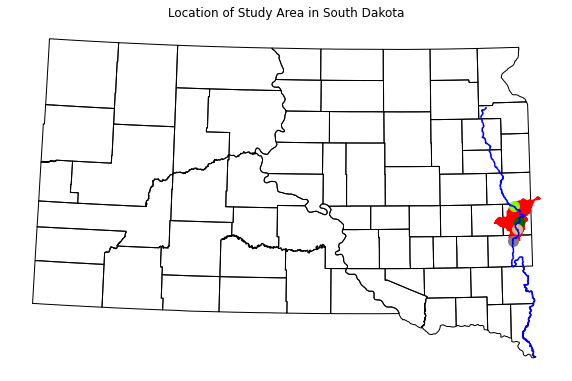

```python
# Paths to study location files
site_boundary_path = os.path.join(working_dir,
                                  'shapefiles',
                                  'project-boundaries',
                                  'site_boundaries.shp')
site_loc_path = os.path.join(working_dir,
                             'shapefiles',
                             'site-locations.csv')

bsr_path = os.path.join(working_dir,
                        "shapefiles",
                        'big-sioux-river',
                        'rivs_mbrfc_projected.shp')

plot_loc_sym = {'BS-10': 'chartreuse',
                'BS-11': 'darkgreen',
                'BS-12': 'burlywood',
                'USGS 06481000': 'gray'}
site_loc_json = os.path.join(working_dir,
                             "outputs",
                             "site.json")

county_boundaries_path = os.path.join(working_dir,
                                      'shapefiles',
                                      'county-boundaries',
                                      'counties_nad83.shp')

# Open study location files
site_boundary = gpd.read_file(site_boundary_path)
county_boundaries = gpd.read_file(county_boundaries_path)
site_locations = pd.read_csv(site_loc_path)
site_loc_gdf = gpd.GeoDataFrame(site_locations, geometry=gpd.points_from_xy(site_locations.easting, site_locations.northing),
                                crs=26914)
bsr = gpd.read_file(bsr_path)

site_json = gpd.read_file(site_loc_json)

# Broad Context Map
fig, ax = plt.subplots(figsize=(10, 10))
ax.set_axis_off()

county_boundaries.plot(ax=ax,
                       color='none',
                       edgecolor='black')

bsr.plot(ax=ax,
         color='blue')


site_boundary.plot(ax=ax,
                   edgecolor='red',
                   color='red')

for i, k in site_loc_gdf.groupby('site_name'):
    color = plot_loc_sym[i]
    label = i
    k.plot(color=color,
           ax=ax,
           label=label,
           markersize=100)

ax.set(title="Location of Study Area in South Dakota")
plt.show()
```

```python
# Create folium map

m = folium.Map(location=[43.9978, -96.6376],
               tiles='Stamen Terrain',
               zoom_start=10)

for i, k in site_loc_gdf.groupby('site_name'):
    folium.Marker(location=[k.lat, k.long],
                  popup=i,
                  icon=folium.Icon()).add_to(m)

folium.GeoJson(site_json, name="geojson").add_to(m)

m
```

Make this Notebook Trusted to load map: File -> Trust Notebook

[interactive chart not shown]

```python
# Paths to groundwater chemistry data
bs_10_path = os.path.join("chemistry", "bs-10.csv")
bs_11_49_path = os.path.join("chemistry", "R20-89-49-inorg-data.csv")
bs_11_50_path = os.path.join("chemistry", "R20-89-50-inorg-data.csv")
bs_12_path = os.path.join("chemistry", "bs-12.csv")

# Paths to surfacewater chemistry data
surf_water_path = os.path.join(
    "chemistry", "06481000-daily-data-4-7-2017-4-1-2021.csv")

# Import groundwater chemistry data
gw_89_49 = pd.read_csv(bs_11_49_path,
                       parse_dates=['COLLECTION_DATE'],
                       index_col=['COLLECTION_DATE'],
                       na_values=' ')
gw_89_50 = pd.read_csv(bs_11_50_path,
                       parse_dates=["COLLECTION_DATE"],
                       index_col=['COLLECTION_DATE'],
                       na_values=' ')

gw_bs_10_df = pd.read_csv(bs_10_path,
                          parse_dates=["collection_date"],
                          index_col=['collection_date'],
                          na_values=' ')

gw_bs_12_df = pd.read_csv(bs_12_path,
                          parse_dates=["collection_date"],
                          index_col=['collection_date'],
                          na_values=' ')

# Combine 49 and 50
frames = [gw_89_50, gw_89_49]
gw_bs_11_df = pd.concat(frames)

# Import surface water chemistry data
sur_water = pd.read_csv(surf_water_path,
                        parse_dates=["datetime"],
                        index_col=['datetime'],
                        na_values=' ')
```

# Ground water nitrate data

Let's take a look at the nitrate data available at the four sites shown above.

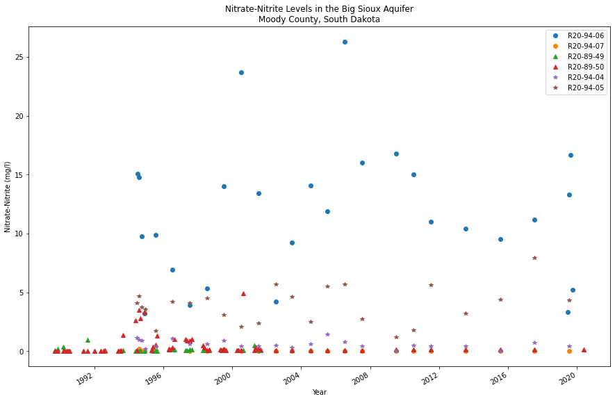

```python
# Create time series plots for groundwater wells to assess the data
bs_10_plot = gw_bs_10_df.reset_index()
bs_11_plot = gw_bs_11_df.reset_index()
bs_12_plot = gw_bs_12_df.reset_index()

# Plot groundwater data
fig, ax = plt.subplots(figsize=(15, 10))

for i, k in bs_10_plot.groupby(['sdgs_well']):
    k.groupby(['sdgs_well']).plot(x='collection_date',
                                  y="No2_No3_N_Num",
                                  label=i,
                                  style=' ',
                                  marker='o',
                                  ax=ax)
for i, k in bs_11_plot.groupby(['SDGS_WELL']):
    k.groupby(['SDGS_WELL']).plot(x='COLLECTION_DATE',
                                  y='NO3_NO2',
                                  label=i,
                                  style=' ',
                                  marker='^',
                                  ax=ax)

for i, k in bs_12_plot.groupby(['sdgs_well']):
    k.groupby(['sdgs_well']).plot(x="collection_date",
                                  y="No2_No3_N_Num",
                                  label=i,
                                  style=' ',
                                  marker='*',
                                  ax=ax)
ax.set(title='Nitrate-Nitrite Levels in the Big Sioux Aquifer\nMoody County, South Dakota',
       xlabel='Year',
       ylabel='Nitrate-Nitrite (mg/l)')
plt.show()
```

In the plot above we have 6 groundwater wells. Each site has two wells, one shallow and one deep. The well pairs look at nitrate stratification in the aquifer. The shallow wells typically contain higher nitrate values. In this plot I'm looking for temporal and geographical trends in nitrate values. The wells in the legend or organized north to south. I'm seeing very high nitrate values (10+ mg/l) in the northern shallow well (blue dots), very low nitrate values (<1 mg/l) in the middle wells (green and red triangles) and moderate levels of nitrate (between 1 and 10 mg/l) in the southern wells (brown and purple stars).

That trend is a tough one to explain. I'd think that nitrate values would be more closely linked with regional water flow but there are low values in the middle of two higher values. This can mean a lot of things especially since nitrate concentrations can accumulate over time in an aquifer but one thing that this study can shed light on is whether or not ground water nitrate values are varying with crop growth, harvest, or known fertilizing times.

# Surface water nitrate data

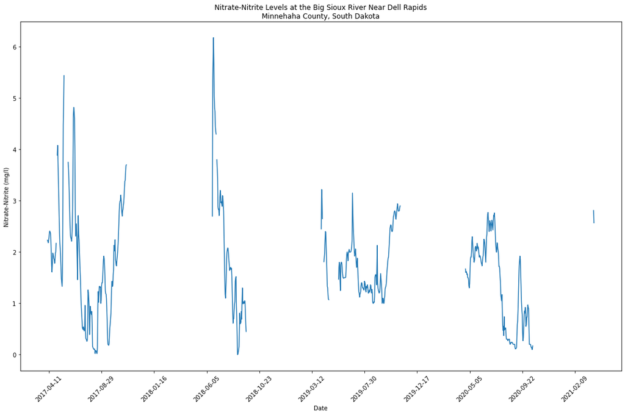

```python
# Create time series plot for surface water to assess the data

fig, ax = plt.subplots(figsize=(15, 10))

ax.plot(sur_water.index,
        sur_water['mean_nitrate_nitrite'],
        label='Station 06481000')

ax.xaxis.set_major_locator(mdates.WeekdayLocator(interval=20))
plt.setp(ax.get_xticklabels(), rotation=45)

ax.set(title='Nitrate-Nitrite Levels at the Big Sioux River Near Dell Rapids\nMinnehaha County, South Dakota',
       xlabel="Date",
       ylabel="Nitrate-Nitrite (mg/l)")
plt.tight_layout()
plt.show()
```

The surface water insitu nitrate probe installed by the USGS has a continuous record throughout the spring summer and fall months from 2017 to present. I can see a general seasonal trend in nitrate values with high values in the early summer months and low values in the mid summer and higher values in fall months. I think these trends are tied to farming activity, early summer months would be about the times fertilizer would be applied and some leaching may work its way into the river. While mid summer months crops are grown enough to uptake any nitrate. Remaining nitrates from fertilizer and naturally occurring nitrate in the soil may leach back into the system post harvest in early fall.

Let's take a look at NDVI data derived from Landsat 8 imagery.

# Landsat derrived NDVI data

```python
# Open and process landsat data
# Paths to data
proj_extents = os.path.join(working_dir,
                            "shapefiles",
                            "project-boundaries",
                            "project_boundary.shp")

os.chdir('D:')
landsat_path = os.path.join("landsat",
                            "Bulk_Order_nitrate-study",
                            "Landsat_8_OLI_TIRS_C2_L2")

# Open project boundaries
proj_bound = gpd.read_file(proj_extents)
proj_bound_32614 = proj_bound.to_crs(32614)

# List of band paths
landsat_list = sorted(glob(os.path.join(landsat_path, "LC08*")))

site_name = 'Moody County'
vals = [22280,
        24088, 24216, 24344, 24472, 55052, 56856, 56984, 57240]

ndvi_mean = []
ndvi_max = []
date_list = []
site_list = []
for i in landsat_list:
    band_paths = sorted(glob(os.path.join(i, "*B*[4-5].tif")))

    pixel_qa_path = sorted(glob(os.path.join(i, "*QA_PIXEL*")))

    ndvi_df = pd.DataFrame()
    basenames = os.path.basename(i)
    dates = basenames[17: 25]
    date_list.append(dates)
    out_xr = []
    for band, tif_path in enumerate(band_paths):

        out_xr.append(open_clean_bands(band_path=tif_path,
                                       crop_extent=proj_bound_32614,
                                       valid_range=(7273, 43636)))
        out_xr[band]["band"] = band+1

    xr.concat(out_xr, dim="band")

    for k in pixel_qa_path:
        ndvi = mask_crop_ndvi(all_bands=out_xr,
                              crop_bound=proj_bound_32614,
                              pixel_qa_path=k,
                              vals=vals)
    with warnings.catch_warnings():
        warnings.simplefilter("ignore", category=RuntimeWarning)

        mean_ndvi = np.nanmean(ndvi)
        max_ndvi = np.nanmax(ndvi)
        ndvi_mean.append(mean_ndvi)
        ndvi_max.append(max_ndvi)
        site_list.append(site_name)
        ndvi_df["date"] = date_list
        ndvi_df["site"] = site_list
        ndvi_df['mean_ndvi'] = ndvi_mean
        ndvi_df['max_ndvi'] = ndvi_max

ndvi_df["date"] = pd.to_datetime(ndvi_df["date"])
ndvi_df.set_index("date", inplace=True)
```

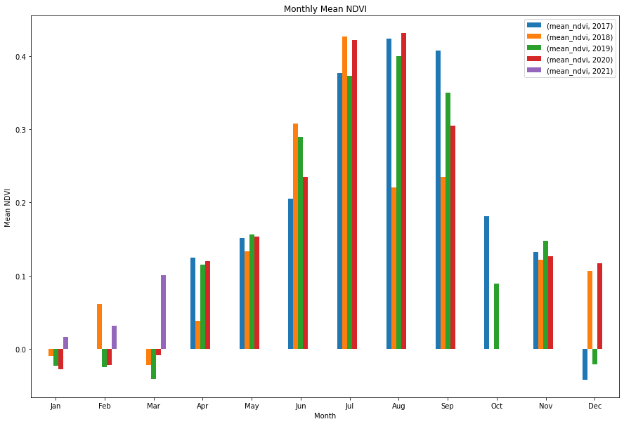

```python
# Plot NDVI data
ndvi_df.dropna(inplace=True)
ndvi_df['day'] = ndvi_df.index.dayofyear
ndvi_df['year'] = ndvi_df.index.year
ndvi_df['month'] = ndvi_df.index.month

months_array = ['Jan', 'Feb', 'Mar', 'Apr', 'May',
                'Jun', 'Jul', 'Aug', 'Sep', 'Oct', 'Nov', 'Dec']
month_starts = [0, 1, 2, 3, 4, 5, 6, 7, 8, 9, 10, 11]

piv_table = pd.pivot_table(ndvi_df, index=['month'], columns=[
                           'year'], values=['mean_ndvi'])
fig, ax = plt.subplots(figsize=(15, 10))
piv_table.plot.bar(ax=ax).legend(loc='best')

plt.setp(ax.get_xticklabels(), rotation=0)

ax.set_xticks(month_starts)
ax.set_xticklabels(months_array)

ax.set(ylabel='Mean NDVI',
       xlabel='Month',
       title='Monthly Mean NDVI')
plt.show()
```

The above plot shows the average monthly NDVI for 5 years of data. As one might expect NDVI increases during spring and summer months and decreases during fall and winter months.

# Linear regression results

Lets look at a regression between NDVI and ground water and surface water nitrate data.

```python
# Resample both surf water dataframe and NDVI dataframe
sur_water_month = sur_water.resample('M').agg(
    {'mean_nitrate_nitrite': ['max', 'mean']})
sur_water_month.columns = sur_water_month.columns.map('-'.join)

ndvi_month = ndvi_df.resample('M').mean()
ndvi_month_drop = ndvi_month.dropna()
sur_water_month_drop = sur_water_month.dropna()

# Tease out NDVI data to match monthly sur_water data for regression
ndvi_month_2017 = ndvi_month_drop.loc['2017-04-01':'2017-11-30']
ndvi_month_2018 = ndvi_month_drop.loc['2018-06-01':'2018-09-30']
ndvi_month_2019 = ndvi_month_drop.loc['2019-04-01':'2019-11-30']
ndvi_month_2020 = ndvi_month_drop.loc['2020-04-01':'2020-09-30']
frames = [ndvi_month_2017, ndvi_month_2018, ndvi_month_2019, ndvi_month_2020]
ndvi_month_concat = pd.concat(frames)
ndvi_month_mean_reg = ndvi_month_concat[['mean_ndvi']]
ndvi_month_max_reg = ndvi_month_concat[['max_ndvi']]

# Filter out sur water data
df = sur_water_month_drop.reset_index()
sur = df.drop([26, 27, 28])
sur_reg = sur.set_index('datetime')

sur_month_mean_reg = sur_reg[['mean_nitrate_nitrite-mean']]
sur_month_max_reg = sur_reg[['mean_nitrate_nitrite-max']]

# Filter out groundwater data
# Subset groundwater data

bs_10_2017_2021 = gw_bs_10_df.sort_index().loc['2017-01-01':'2021-04-01']
bs_11_2017_2021 = gw_bs_11_df.sort_index().loc['2017-01-01':'2021-04-01']
bs_12_2017_2021 = gw_bs_12_df.sort_index().loc['2017-01-01':'2021-04-01']

# Rename columns and subset data for shallow wells
bs_10_2017_2021['NO3_NO2'] = bs_10_2017_2021['No2_No3_N_Num']
bs_12_2017_2021['NO3_NO2'] = bs_12_2017_2021['No2_No3_N_Num']

r20_94_06_17_21 = bs_10_2017_2021.loc[bs_10_2017_2021['sdgs_well'] == 'R20-94-06']
r20_94_05_17_21 = bs_12_2017_2021.loc[bs_12_2017_2021['sdgs_well'] == 'R20-94-05']
r20_89_50_17_21 = bs_11_2017_2021.loc[bs_11_2017_2021['SDGS_WELL'] == 'R20-89-50']
```

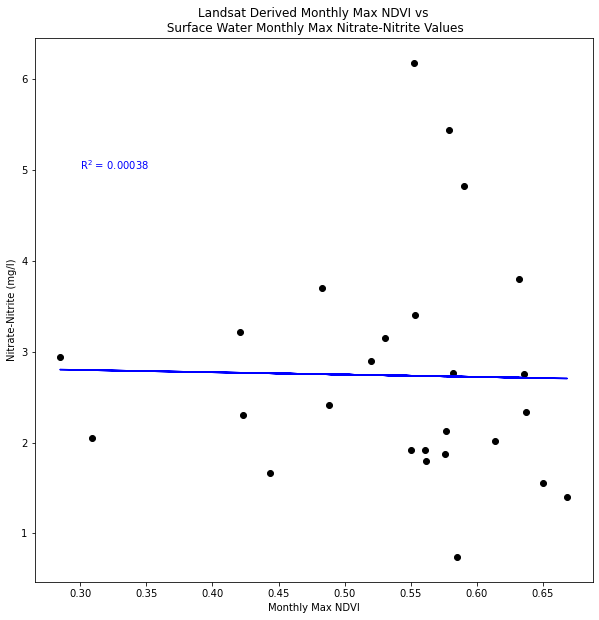

```python
# Perform linear regression for max values
# Convert to numpy arrays
ndvi_max_array = ndvi_month_max_reg.to_numpy()
sur_water_max_array = sur_month_max_reg.to_numpy().reshape(-1)

x = ndvi_max_array
y = sur_water_max_array

model = LinearRegression().fit(x, y)
y_pred = model.predict(x)
r_sq = model.score(x, y)
slope = model.coef_
r_sq, slope, model.intercept_
fig, ax = plt.subplots(figsize=(10, 10))

ax.scatter(x, y,
           color='black')
ax.plot(x, y_pred, color='blue')

ax.set(xlabel="Monthly Max NDVI",
       ylabel="Nitrate-Nitrite (mg/l)",
       title="Landsat Derived Monthly Max NDVI vs\n Surface Water Monthly Max Nitrate-Nitrite Values"
       )
ax.text(.3, 5, 'R$^2$ = 0.00038', color='blue')
plt.show()
```

The above plot is a linear regression between monthly max NDVI and monthly max surface water nitrate data.

[figure not shown]

```python
# Plot NDVI for mean values
ndvi_mean_array = ndvi_month_mean_reg.to_numpy()
sur_water_mean_array = sur_month_mean_reg.to_numpy()

x = ndvi_mean_array
y = sur_water_max_array

model = LinearRegression().fit(x, y)
y_pred = model.predict(x)
r_sq = model.score(x, y)
slpe = model.coef_

fig, ax = plt.subplots(figsize=(10, 10))

ax.scatter(x, y,
           color='black')
ax.plot(x, y_pred, color='blue')

ax.set(xlabel="Monthly Mean NDVI",
       ylabel="Nitrate-Nitrite (mg/l)",
       title="Landsat Derived Monthly Mean NDVI vs\n Surface Water Monthly Mean Nitrate-Nitrite Values"
       )
ax.text(.3, 5, 'R$^2$ = 0.076', color='blue')

plt.show()
```

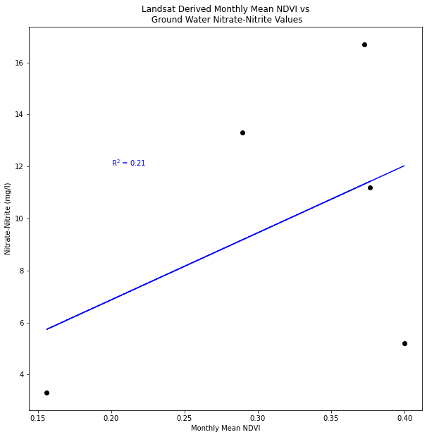

```python
# Analyze Groundwater wells
ndvi_gw = ndvi_month_mean_reg.reset_index()
ndvi_gw_reg = ndvi_gw.loc[[3, 13, 14, 15, 16]]
ndvi_gw_reg = ndvi_gw_reg.set_index('date')
gw_reg = r20_94_06_17_21[['NO3_NO2']]
ndvi_mean_gw_array = ndvi_gw_reg.to_numpy()
gw_reg_array = gw_reg.to_numpy()

x = ndvi_mean_gw_array
y = gw_reg_array

model = LinearRegression().fit(x, y)
y_pred = model.predict(x)

r_sq = model.score(x, y)
slope = model.coef_
fig, ax = plt.subplots(figsize=(10, 10))

ax.scatter(x, y,
           color='black')
ax.plot(x, y_pred, color='blue')

ax.set(xlabel="Monthly Mean NDVI",
       ylabel="Nitrate-Nitrite (mg/l)",
       title="Landsat Derived Monthly Mean NDVI vs\n Ground Water Nitrate-Nitrite Values"
       )
ax.text(.2, 12, 'R$^2$ = 0.21', color='blue')

plt.show()
```

This brief analysis was an exploration of nitrate and NDVI data. In the weeks to come, I will account for some of the many confounding variables and try a more advanced machine learning approach to analyze the data. This may yield more conclusive results and answer the questions I have about nitrate levels in surface water and surficial aquifers.

Sources Guiding my Next Steps

[Gap-filled water quality, Normalized Differenced Vegetation Index, total nitrogen (nitrate and ammonia) deposition, and land cover data trends for the Continental United States](https://data.ess-dive.lbl.gov/view/doi:10.15485/1647366)

[A PHENOLOGICAL APPROACH TO LAND COVER CHARACTERIZATION USING LANDSAT MSS DATA FOR ANALYSIS OF NONPOINT SOURCE POLLUTION](http://kufs.ku.edu/media/uploads/work/kars_report_96-1.pdf)

[Normalized difference vegetation index as the dominant predicting factor of groundwater recharge in phreatic aquifers: case studies across Iran](https://www.nature.com/articles/s41598-020-74561-4)

[INTERRELATIONSHIPS AMONG LANDSCAPES, NDVI, AND STREAM WATER QUALITY IN THE U.S. CENTRAL PLAINS](https://esajournals.onlinelibrary.wiley.com/doi/10.1890/1051-0761%282002%29012%5B1702%3AIALNAS%5D2.0.CO%3B2)

[Applying the remotely sensed data to identify homogeneous regions of watersheds using a pixel-based classification approach](https://www.sciencedirect.com/science/article/abs/pii/S0143622819301869)

[Feature selection approaches for predictive modelling of groundwater nitrate pollution: An evaluation of filters, embedded and wrapper methods](https://www.sciencedirect.com/science/article/abs/pii/S0048969717335751)